# Sentiment Analysis

### Word Clouds

With the data organized we can also create useful visualizations without the use of ggplot. At times, a word cloud can be helpful in displaying the commonality of words in the text. Take a look here as this word cloud displays the count of the first 100 most common words from all Jane Austen books in this package.

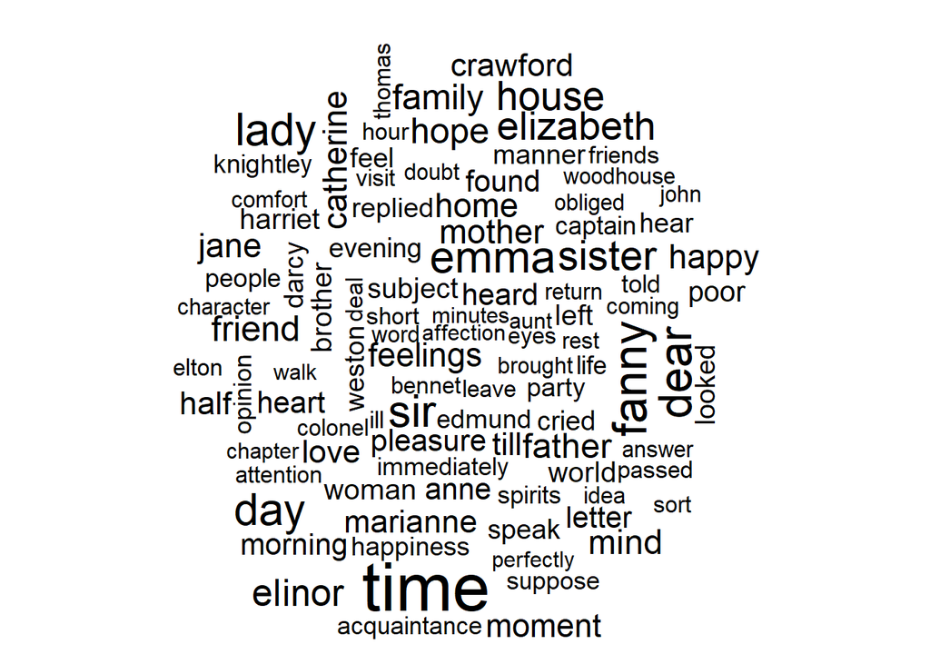

```r
tidy_books %>%
  anti_join(stop_words) %>%
  count(word) %>%
  with(wordcloud(word, n, max.words = 100))
```

In a word cloud, the size of the word represents the count of the words in the text overall. The larger the size of the word, the more frequently it occurs in the text. We can also use word clouds for comparison.

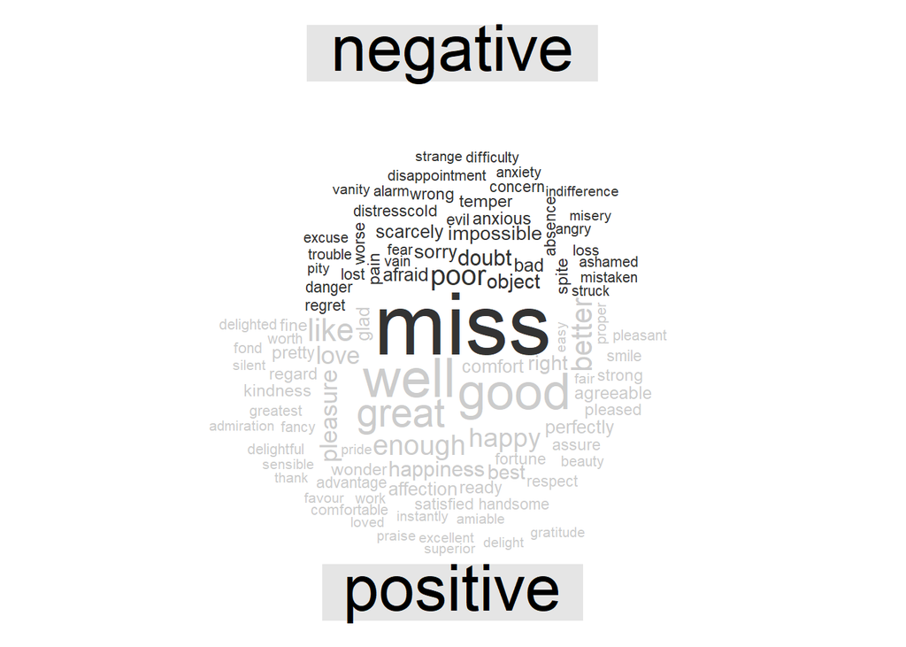

```r
tidy_books %>%
  inner_join(get_sentiments("bing")) %>%
  count(word, sentiment, sort = TRUE) %>%
  acast(word ~ sentiment, value.var = "n", fill = 0) %>%
  comparison.cloud(colors = c("gray20", "gray80"),
                   max.words = 100)
```

For comparing positive and negative words this word cloud separates the positives in a lighter shade to negatives in a darker shade. The closer the words are to the positive at the bottom, the more positive the sentiment. The more negative the word, the closer it is to the top of the word cloud.

### Sentence Sentiment

When we are reading, often the context of the word plays an important part in the sentiment of the word. In fact, the entire sentence can have its own sentiment depending on negation and other surrounding words. We can consider the sentences another option to review to understand sentiment. Let’s use the book Pride and Prejudice again.

```r
# Extracting the sentences of pride and prejudice
PandP_sentences <- tibble(text = prideprejudice) %>%
  unnest_tokens(sentence, text, token = "sentences")
# Viewing one sentence
PandP_sentences$sentence[2]
```

```
## [1] "however little known the feelings or views of such a man may be on his first entering a neighbourhood, this truth is so well fixed in the minds of the surrounding families, that he is considered the rightful property of some one or other of their daughters."
```

This sentence can then be analyzed in a variety of ways. We start by counting the chapters in each book available in the tidytext package. This process is a repeat where the regular expression separates the books into chapters and the result is summarized through another count of those separations.

```r
austen_chapters <- austen_books() %>%
  group_by(book) %>%
  unnest_tokens(chapter, text, token = "regex",
                pattern = "Chapter|CHAPTER [\\dIVXLC]") %>%
  ungroup()

chpt_austen <- austen_chapters %>%
  group_by(book) %>%
  summarise(chapters = n())
rmarkdown::paged_table(chpt_austen)
```

| book | chapters |
| --- | --- |
| Sense & Sensibility | 51 |
| Pride & Prejudice | 62 |
| Mansfield Park | 49 |
| Emma | 56 |
| Northanger Abbey | 32 |
| Persuasion | 25 |

Now we can find the overall sentiment in each chapter by reviewing each row which contains a sentence. It is then natural to repeat the process by finding the number of negative words and dividing by the total words in each chapter to compute the overall sentiment for those chapters.

```r
# Collect the negative sentiment words from bing lexicon
bingnegative <- get_sentiments("bing") %>%
  filter(sentiment == "negative")
# Group the chapters by book titles and tally their total words
wordcounts <- tidy_books %>%
  group_by(book, chapter) %>%
  summarize(words = n())
# Calculate the sentiment of each chapter and select the highest from each book
bingnegs <- tidy_books %>%
  semi_join(bingnegative) %>%
  group_by(book, chapter) %>%
  summarize(negativewords = n()) %>%
  left_join(wordcounts, by = c("book", "chapter")) %>%
  mutate(ratio = negativewords/words) %>%
  filter(chapter != 0) %>%
  top_n(1) %>%
  ungroup()
rmarkdown::paged_table(bingnegs)
```

| book | chapter | negativewords | words | ratio |
| --- | --- | --- | --- | --- |
| Sense & Sensibility | 43 | 161 | 3405 | 0.04728341 |
| Pride & Prejudice | 34 | 111 | 2104 | 0.05275665 |
| Mansfield Park | 46 | 173 | 3685 | 0.04694708 |
| Emma | 15 | 151 | 3340 | 0.04520958 |
| Northanger Abbey | 21 | 149 | 2982 | 0.04996647 |
| Persuasion | 4 | 62 | 1807 | 0.03431101 |

## Analysis

For this analysis we will repeat this process on the Harry Potter novels by J.K. Rowling. The loughran lexicon will be our primary lexicon instead of AFINN, Bing, or NRC. We will also compare the loughran lexicon to our other lexicons. These books were made available in a package hosted on Github by Bradley Boehmke. For this assignment the URL to access this data is available here: https://github.com/bradleyboehmke/harrypotter/tree/master/data

### Basics

We need a place to store the information and ensure it is clean enough to work with. In this section will gather the titles of all the books into one list then fill that list with all the information that follows the title from the url. These steps are outlined in the code below.

```r
# Create titles list
titles <- c("Philosopher's Stone",
            "Chamber of Secrets",
            "Prisoner of Azkaban",
            "Goblet of Fire",
            "Order of the Phoenix", "Half-Blood Prince",
            "Deathly Hallows")
# Fill titles list with contents of each book
books <- list(philosophers_stone,
              chamber_of_secrets,
              prisoner_of_azkaban,
              goblet_of_fire,
              order_of_the_phoenix,
              half_blood_prince,
              deathly_hallows)
# Create an empty tibble
series <- tibble()
# Using the title follow this sequence to...
for(i in seq_along(titles)) {
        # extract the books by title
        clean <- tibble(chapter = seq_along(books[[i]]),
                        text = books[[i]]) %>%
             unnest_tokens(word, text) %>%
             mutate(book = titles[i]) %>%
             select(book, everything())
        # Include all the information contained in it
        series <- rbind(series, clean)
}
# Use an ordered factor to keep the books in chronological order
series$book <- factor(series$book, levels = rev(titles))
# Perform a right join using the loughran lexicon
lough_tbl <- series %>%
        right_join(get_sentiments("loughran")) %>%
        filter(!is.na(sentiment)) %>%
        count(sentiment, sort = TRUE)
rmarkdown::paged_table(lough_tbl)
```

| sentiment | n |
| --- | --- |
| negative | 16059 |
| uncertainty | 8838 |
| positive | 7075 |
| litigious | 1785 |
| constraining | 777 |
| superfluous | 61 |

Immediately we notice that this lexicon has different sentiment options than than AFINN, Bing, or NRC. In addition to negative and positive sentiments, words can be organized into the new categories of litigious, constraining, superfluous, and uncertainty. Keep this is mind as it changes our analysis.

For our purposes, this table is great for a quick check of the counts of words and their sentiment on the loughran scale, but a better visual might be a bar chart by index. If organized for each index number as we completed in the review of *Text Analysis with R* we may be able to see these changes over time for each book. For easy comparisons, we will only look at the positive and negative sentiments in this visual.

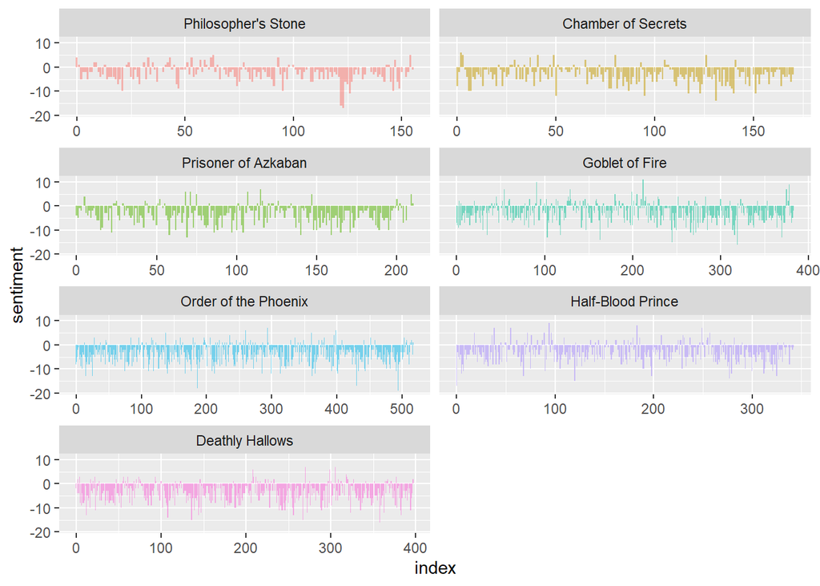

```r
series %>%
        group_by(book) %>%
        mutate(word_count = 1:n(),
               index = word_count %/% 500) %>%
        inner_join(get_sentiments("loughran")) %>%
        count(book, index = index , sentiment) %>%
        ungroup() %>%
        spread(sentiment, n, fill = 0) %>%
        mutate(sentiment = positive - negative,
               book = factor(book, levels = titles)) %>%
        ggplot(aes(index, sentiment, fill = book)) +
          geom_bar(alpha = 0.5, stat = "identity", show.legend = FALSE) +
          facet_wrap(~ book, ncol = 2, scales = "free_x")
```

As in our review, there is variation in the plot of each novel. However, these novels contain many more words that give a negative sentiment. We can see this in the mostly negative level and scales of each book across its plot. Though these books are largely based on negative sentiments we should consider the possibility that it is this lexicon that causes such a shift in sentiment.

### Comparing Lexicons

Did the loughran lexicon cause the sentiment of the Harry Potter series to appear more negative than it actually is? Is there a clear difference in this loughran lexicon when compared to Bing or NRC over the same series of text? We can create a few more examples to compare.

```r
# repeat of inner joins, group and summarise, over lines by index for loughran lexicon
chamber_lough <- series %>%
        group_by(book) %>%
        filter(book == "Chamber of Secrets") %>%
        mutate(word_count = 1:n(),
               index = word_count %/% 500) %>%
        inner_join(get_sentiments("loughran")) %>%
        count(book, index = index , sentiment) %>%
        ungroup() %>%
        spread(sentiment, n, fill = 0) %>%
        mutate(sentiment = positive - negative,
               book = factor(book, levels = titles)) %>%
    mutate(method = "loughran")
# repeat of inner joins, group and summarise, over lines by index for nrc lexicon
chamber_nrc <- series %>%
        group_by(book) %>%
        filter(book == "Chamber of Secrets") %>%
        mutate(word_count = 1:n(),
               index = word_count %/% 500) %>%
        inner_join(get_sentiments("nrc")) %>%
        count(book, index = index , sentiment) %>%
        ungroup() %>%
        spread(sentiment, n, fill = 0) %>%
        mutate(sentiment = positive - negative,
               book = factor(book, levels = titles)) %>%
    mutate(method = "nrc")
# repeat of inner joins, group and summarise, over lines by index for bing lexicon
chamber_bing <- series %>%
        group_by(book) %>%
        filter(book == "Chamber of Secrets") %>%
        mutate(word_count = 1:n(),
               index = word_count %/% 500) %>%
        inner_join(get_sentiments("bing")) %>%
        count(book, index = index , sentiment) %>%
        ungroup() %>%
        spread(sentiment, n, fill = 0) %>%
        mutate(sentiment = positive - negative,
               book = factor(book, levels = titles)) %>%
    mutate(method = "bing")
```

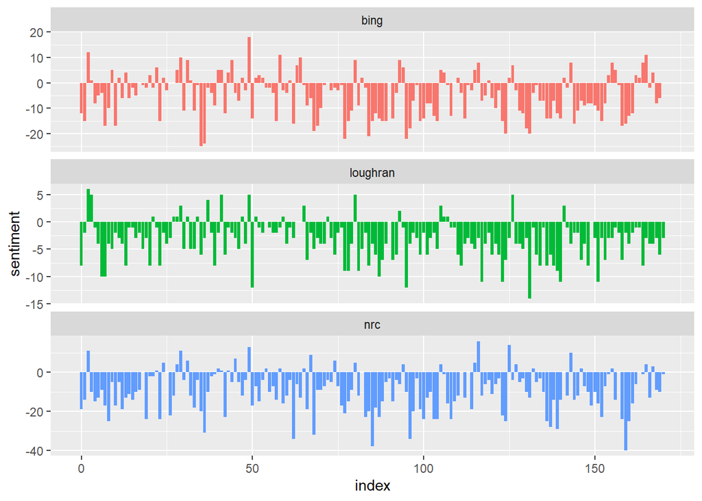

```r
# Create equal number of columns for binding
bing_cos <- subset(chamber_bing, select = c("index", "sentiment", "method"))
nrc_cos <- subset(chamber_nrc, select = c("index", "sentiment", "method"))
lough_cos <- subset(chamber_lough, select = c("index", "sentiment", "method"))
# Bind them by rows with method as the identifier of lexicon
rbind(bing_cos,
        nrc_cos,
          lough_cos) %>%
  # Visualize the distribution over the lines by lexicon type
  ggplot(aes(index, sentiment, fill = method)) +
  geom_col(show.legend = FALSE) +
  facet_wrap(~method, ncol = 1, scales = "free_y")
```

It is interesting to see the similarity between the lexicons. Now, recall the additional categories of uncertainty, litigious, superfluous, and constraining words that we found in the basic quick check of these books. There is more to the lexicon than simply positive or negative words. We can visualize this for simplicity.

```r
lough_words <- series %>%
  inner_join(get_sentiments("loughran")) %>%
  count(word, sentiment, sort = TRUE) %>%
  ungroup()
```

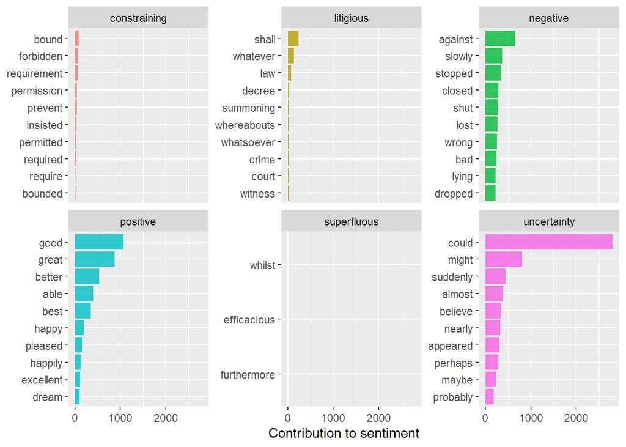

```r
lough_words %>%
        group_by(sentiment) %>%
        top_n(10) %>%
ggplot(aes(reorder(word, n), n, fill = sentiment)) +
          geom_bar(alpha = 0.8, stat = "identity",
                   show.legend = FALSE) +
          facet_wrap(~sentiment, scales = "free_y") +
          labs(y = "Contribution to sentiment", x = NULL) +
          coord_flip()
```

We can also see the positive words of good, great, better, and so on, creating another sentiment that adds to the positive sentiment throughout the books. At times, often when the protagonist is faced with challenges, the contrast between positives and negatives help to create the heroes we have come to know in each book. In this case, the most influential negative word is against. There is also a small number of influential litigious and constraining words but nearly none are superfluous when considering the sentiment of words throughout the series.

It may be interesting to take a dive into one of the books. As we did in the review with Jane Austen’s Pride and Prejudice, we can extract a few sentence examples to see how the Chamber of Secrets by J.K. Rowling, is written.

```r
# Extract the sentences from chapter 1 through the book
chamber_sentences <- tibble(chapter = 1:length(chamber_of_secrets),
                  text = chamber_of_secrets) %>%
                  unnest_tokens(sentence, text, token = "sentences")
head(chamber_sentences[50:70,], 3)
```

```
## # A tibble: 3 x 2
##   chapter sentence
##     <int> <chr>
## 1       1 harry, on the other hand, was small and skinny, with brilliant green ~
## 2       1 he wore round glasses, and on his forehead was a thin, lightning-shap~
## 3       1 it was this scar that made harry so particularly unusual, even for a ~
```

The name “Harry” is used quite frequently in this example. Given that he is the main character it was likely that we would see his name more frequently than the rest. I would expect to see his immediate friends’ names, Ron and Herminone, to closely follow in commonality. Before getting to that, let’s review the sentiment across chapters in this book by sentences in the Chamber of Secrets, for context.

```r
chamber_lines <- chamber_sentences %>%
        group_by(chapter) %>%
        mutate(sentence_num = 1:n(),
               index = round(sentence_num / n(), 2)) %>%
        unnest_tokens(word, sentence) %>%
        inner_join(get_sentiments("loughran")) %>%
        group_by(chapter, index)
```

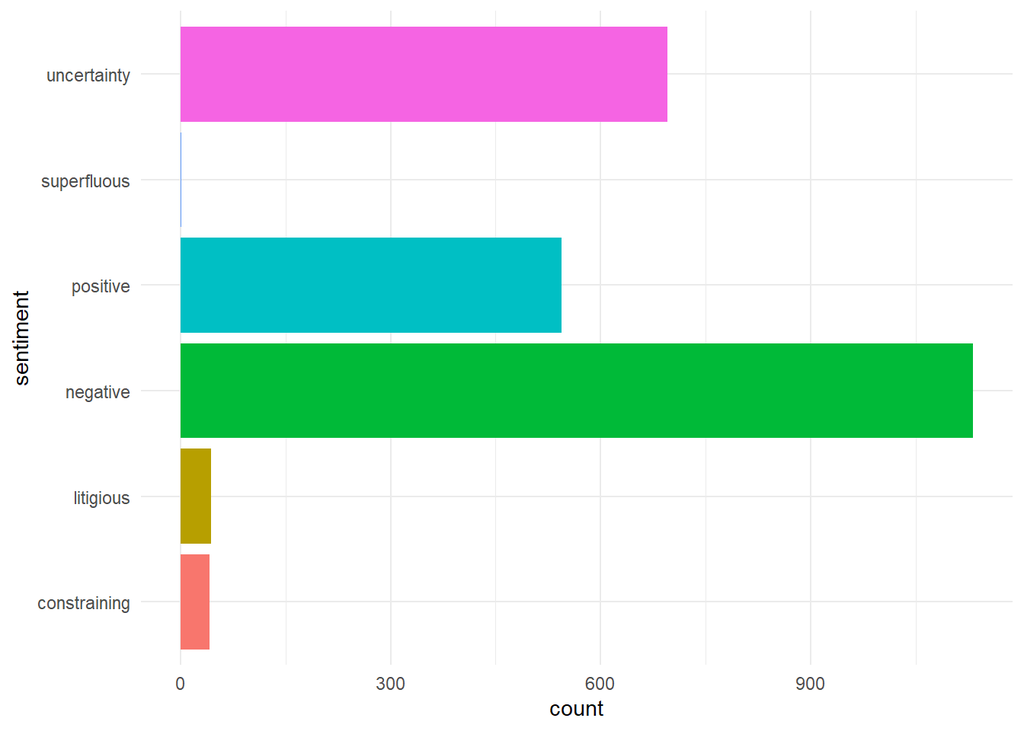

```r
# Visualize as columns
ggplot(chamber_lines, aes(sentiment, fill = sentiment)) + geom_bar(show.legend = FALSE) + theme_minimal() + coord_flip()
```

```r
# Find the negative sentiment words of the loughran lexicon
loughnegs <- get_sentiments("loughran") %>%
  filter(sentiment == "negative")
# Count the total words by chapter in each book
wordcounts <- series %>%
  group_by(book, chapter) %>%
  summarize(words = n())
# Repeat review process - join negative loughran words with data, classify words by chapter,
# summarize sentiment and create a new column with the ratio of sentiment to total words by chapter
# lastly, select the top ratio of each chapter with the data and display it
lough_mostnegchpts_ofbooks <- series %>%
  semi_join(loughnegs) %>%
  group_by(book, chapter) %>%
  summarize(sentiment = n()) %>%
  left_join(wordcounts, by = c("book", "chapter")) %>%
  mutate(ratio = (sentiment/words)) %>%
  filter(chapter != 0) %>%
  top_n(1) %>%
  ungroup()
# Organize the ratio in descending order
lough_mostnegchpts_ofbooks <- lough_mostnegchpts_ofbooks %>%
  arrange(desc(ratio))
# round the ratio for visuals
lough_mostnegchpts_ofbooks$ratio <- signif(lough_mostnegchpts_ofbooks$ratio, digits=3)
# display information as a table
rmarkdown::paged_table(lough_mostnegchpts_ofbooks)
```

| book | chapter | sentiment | words | ratio |
| --- | --- | --- | --- | --- |
| Deathly Hallows | 2 | 90 | 4086 | 0.0220 |
| Philosopher's Stone | 15 | 104 | 5104 | 0.0204 |
| Half-Blood Prince | 1 | 104 | 5127 | 0.0203 |
| Order of the Phoenix | 27 | 146 | 7515 | 0.0194 |
| Chamber of Secrets | 16 | 47 | 2550 | 0.0184 |
| Prisoner of Azkaban | 7 | 75 | 4253 | 0.0176 |
| Goblet of Fire | 27 | 108 | 7063 | 0.0153 |

In each chapter we have a ratio given to it. By organizing thse ratio in descending order, we visually pick out the most negative books to least negative books. It is also easy to see the chapter which gave it the most negative sentiment ratio possible but, a better visual might be a column chart.

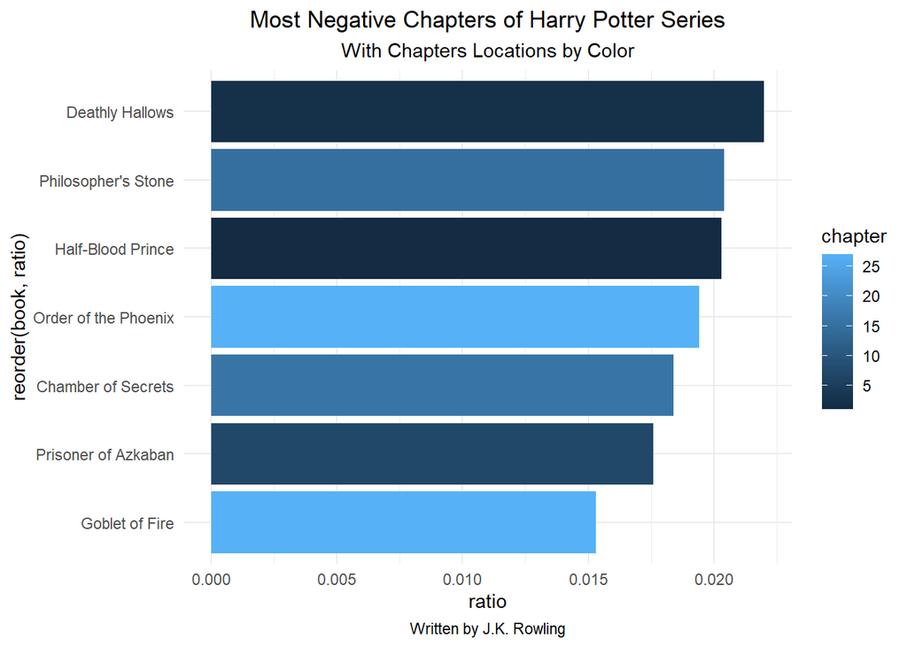

```r
# visualize as a column chart for each book and chapters by location in each book
ggplot(lough_mostnegchpts_ofbooks, aes(x = reorder(book, ratio), y = ratio, fill = chapter)) +
  geom_col(show.legend = TRUE) +
  theme_minimal() +
  labs(title = "Most Negative Chapters of Harry Potter Series",
       xlab = "Percent",
       ylab = "Book Title",
       subtitle = "With Chapters Locations by Color",
       caption = "Written by J.K. Rowling") +
  coord_flip() +
  theme(plot.title = element_text(hjust = 0.5),
        plot.subtitle = element_text(hjust = 0.5),
        plot.caption = element_text(hjust = 0.5))
```

Considering the name “Harry” appeared in the sentences randomly selected and displayed above, we can test how common his name is compared to other words. Our expectation is that his friends, given that they were his companions on nearly every wizarding adventure, will appear at a slightly less but similar frequency. As stated in the review, a word cloud will show us the counts of all the words in the book.

[figure not shown]

```r
series %>%
  anti_join(stop_words) %>%
  count(word) %>%
  with(wordcloud(word, n, max.words = 100))
```

There we have it. Harry’s name, our main character and the person the entire plot revolves around, is the most commonly occurring word of all in this series. His companions and friends, Ron and Herminone, do occur in sequence after his but they are not as common as we would have guessed. If you look, you may notice Dumbledore’s name is coming in close to the same frequencies as Ron and Herminone. In the books, he is sometimes referred to as “professor” as well. If the two frequencies of “Dumbledore” and “professor” were combined, it might be greater in commonality than Ron or Herminone.

This comes as a surprise but, it also makes sense given that Harry often wondered where Dumbledore was and what he knew. We should run this again but with each category of the loughran lexicon to see how a word cloud will separate the frequencies of these words throughout the books. We should not see names appear as these are categorized into the loughran lexicon.

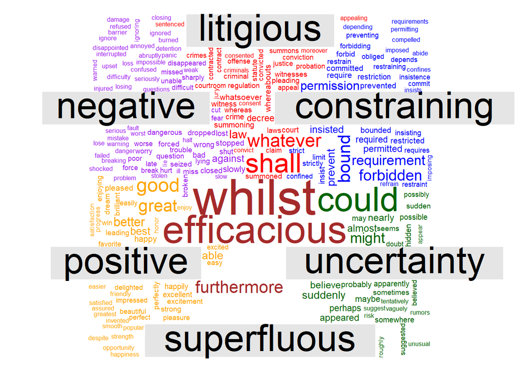

```r
series %>%
  inner_join(get_sentiments("loughran")) %>%

  count(word, sentiment, sort = TRUE) %>%
  acast(word ~ sentiment, value.var = "n", fill = 0) %>%
  comparison.cloud(colors = c("blue", "red", "purple","orange","brown","dark green"),
                   max.words = 300)
```

Using various colors we can see the separation of words into groups easier than if viewing them in black and white. Green represents the sentiment of uncertainty, blue a constraining sentiment, red is litigious, purple is negative, yellow is positive, and brown is superfluous. The word “whilst” is the most common superfluous word and has a larger share of the superfluous frequency making it the largest in this word cloud. However, it is more neutral than the word “efficacious” which, under the loughran lexicon, has a higher superfluous sentiment.

## Conclusion

The loughran lexicon is my preferred lexicon for its sentiment classifiers. To me, this give a better and more practical indication of the text sentiment without going into too much detail in the lexicon itself and it could be applied in fiscal or contractual contexts. In this domain, too much detail could cause the sentiment to appear unorganized and be less thoughtful or impractical. AFINN, Bing, and NRC, each have their own classifiers that work fine. However, their categorization do not seem as practical for applying to real-world financial scenarios. The categories of sentiment presented in the loughran lexicon only enhance our understanding of the text while adding a bit of functionality to this domain. This is why I prefer it over AFINN, Bing, and NRC in this assignment.

## Source

Silge, Julia. Robinson, David. Text Mining with R: A Tidy Approach. 7 March 2020. www.tidytextmining.com.